## **Used Cars Price Prediction**

# The Context:

- While new car sales have witnessed a slowdown in Indian cars market, the used car market has been thriving and is now even larger than the new car market. However, navigating this market can be complex and time-consuming. That's where Cars4U comes in.

# The objective:

- Our pricing model has already gained significant traction in the automotive industry, with several leading dealerships and car rental companies reporting substantial increases in revenue. By leveraging our technology, businesses no longer have to rely on guesswork or spend countless hours conducting market research.

As a Data scientist, need to build pricing model to predict the price of used cars using given dataset.

# Dataset

### **Data Dictionary**

**S.No.** : Serial Number

**Name** : Name of the car which includes Brand name and Model name

**Location** : The location in which the car is being sold or is available for purchase (Cities)

**Year** : Manufacturing year of the car

**Kilometers_driven** : The total kilometers driven in the car by the previous owner(s) in KM

**Fuel_Type** : The type of fuel used by the car (Petrol, Diesel, Electric, CNG, LPG)

**Transmission** : The type of transmission used by the car (Automatic / Manual)

**Owner** : Type of ownership

**Mileage** : The standard mileage offered by the car company in kmpl or km/kg

**Engine** : The displacement volume of the engine in CC

**Power** : The maximum power of the engine in bhp

**Seats** : The number of seats in the car

**New_Price** : The price of a new car of the same model in INR 100,000

**Price** : The price of the used car in INR 100,000 (**Target Variable**)

### **Loading libraries**

```python
import pandas as pd

import numpy as np

import matplotlib.pyplot as plt

import seaborn as sns

# To scale the data using z-score
from sklearn.preprocessing import StandardScaler

from sklearn.model_selection import train_test_split

# Algorithms to use
from sklearn import tree

from sklearn.tree import DecisionTreeRegressor


from sklearn.ensemble import RandomForestClassifier

from sklearn.linear_model import LinearRegression

from sklearn.linear_model import Ridge

from sklearn.linear_model import Lasso

from sklearn.metrics import r2_score

from sklearn.ensemble import (
    BaggingRegressor,
    RandomForestRegressor,
    GradientBoostingRegressor,
    AdaBoostRegressor,
    StackingRegressor,
)

# Metrics to evaluate the model
from sklearn import metrics

from sklearn.metrics import confusion_matrix, classification_report,recall_score,precision_score, accuracy_score

# For tuning the model
from sklearn.model_selection import GridSearchCV
from sklearn.model_selection import RandomizedSearchCV

from sklearn.metrics import make_scorer,mean_squared_error, r2_score, mean_absolute_error

# To ignore warnings
import warnings
warnings.filterwarnings("ignore")
```

### **Let us load the data**

```python
data = pd.read_csv("used_cars.csv")
```

## Data Overview

```python
data.head()
```

|  | S.No. | Name | Location | Year | Kilometers_Driven | Fuel_Type | Transmission | Owner_Type | Mileage | Engine | Power | Seats | New_price | Price |
| --- | --- | --- | --- | --- | --- | --- | --- | --- | --- | --- | --- | --- | --- | --- |
| 0 | 0 | Maruti Wagon R LXI CNG | Mumbai | 2010 | 72000 | CNG | Manual | First | 26.60 | 998.0 | 58.16 | 5.0 | NaN | 1.75 |
| 1 | 1 | Hyundai Creta 1.6 CRDi SX Option | Pune | 2015 | 41000 | Diesel | Manual | First | 19.67 | 1582.0 | 126.20 | 5.0 | NaN | 12.50 |
| 2 | 2 | Honda Jazz V | Chennai | 2011 | 46000 | Petrol | Manual | First | 18.20 | 1199.0 | 88.70 | 5.0 | 8.61 | 4.50 |
| 3 | 3 | Maruti Ertiga VDI | Chennai | 2012 | 87000 | Diesel | Manual | First | 20.77 | 1248.0 | 88.76 | 7.0 | NaN | 6.00 |
| 4 | 4 | Audi A4 New 2.0 TDI Multitronic | Coimbatore | 2013 | 40670 | Diesel | Automatic | Second | 15.20 | 1968.0 | 140.80 | 5.0 | NaN | 17.74 |

## Checking the info of the data

```python
data.info()
```

```
<class 'pandas.core.frame.DataFrame'>
RangeIndex: 7253 entries, 0 to 7252
Data columns (total 14 columns):
 #   Column             Non-Null Count  Dtype
---  ------             --------------  -----
 0   S.No.              7253 non-null   int64
 1   Name               7253 non-null   object
 2   Location           7253 non-null   object
 3   Year               7253 non-null   int64
 4   Kilometers_Driven  7253 non-null   int64
 5   Fuel_Type          7253 non-null   object
 6   Transmission       7253 non-null   object
 7   Owner_Type         7253 non-null   object
 8   Mileage            7251 non-null   float64
 9   Engine             7207 non-null   float64
 10  Power              7078 non-null   float64
 11  Seats              7200 non-null   float64
 12  New_price          1006 non-null   float64
 13  Price              6019 non-null   float64
dtypes: float64(6), int64(3), object(5)
memory usage: 793.4+ KB
```

# Observations

# Let's check the number of unique values in each column.

```python
data.nunique()
```

```
S.No.                7253
Name                 2041
Location               11
Year                   23
Kilometers_Driven    3660
Fuel_Type               5
Transmission            2
Owner_Type              4
Mileage               438
Engine                150
Power                 383
Seats                   8
New_price             625
Price                1373
dtype: int64
```

# Observations

- S.No. is an identifier which is unique for each row. We can drop this column as it would not add any value to our analysis.
- Transmission has only 2 unique value. We can drop this column.

Let's drop S.No. column

```python
data = data.drop(columns=['S.No.'])
```

```python
# Creating numerical columns
num_cols = ['Year','Kilometers_Driven','Mileage','Engine','Power','Seats','New_price','Price']

# Creating categorical variables
cat_cols =  ['Name','Location','Fuel_Type','Transmission','Owner_Type']
```

## **Exploratory Data Analysis**

- EDA is an important part of any project involving data.

```python
data[num_cols].describe().T
```

|  | count | mean | std | min | 25% | 50% | 75% | max |
| --- | --- | --- | --- | --- | --- | --- | --- | --- |
| Year | 7253.0 | 2013.365366 | 3.254421 | 1996.00 | 2011.000 | 2014.00 | 2016.0000 | 2019.00 |
| Kilometers_Driven | 7253.0 | 58699.063146 | 84427.720583 | 171.00 | 34000.000 | 53416.00 | 73000.0000 | 6500000.00 |
| Mileage | 7251.0 | 18.141580 | 4.562197 | 0.00 | 15.170 | 18.16 | 21.1000 | 33.54 |
| Engine | 7207.0 | 1616.573470 | 595.285137 | 72.00 | 1198.000 | 1493.00 | 1968.0000 | 5998.00 |
| Power | 7078.0 | 112.765214 | 53.493553 | 34.20 | 75.000 | 94.00 | 138.1000 | 616.00 |
| Seats | 7200.0 | 5.280417 | 0.809277 | 2.00 | 5.000 | 5.00 | 5.0000 | 10.00 |
| New_price | 1006.0 | 22.779692 | 27.759344 | 3.91 | 7.885 | 11.57 | 26.0425 | 375.00 |
| Price | 6019.0 | 9.479468 | 11.187917 | 0.44 | 3.500 | 5.64 | 9.9500 | 160.00 |

# Observations

# Lets find out what is the issue with data.

```python
# Sort the dataset in 'descending' order using the feature 'Kilometers_Driven'
data.sort_values(by="Kilometers_Driven",ascending=False).head(10)
```

|  | Name | Location | Year | Kilometers_Driven | Fuel_Type | Transmission | Owner_Type | Mileage | Engine | Power | Seats | New_price | Price |
| --- | --- | --- | --- | --- | --- | --- | --- | --- | --- | --- | --- | --- | --- |
| 2328 | BMW X5 xDrive 30d M Sport | Chennai | 2017 | 6500000 | Diesel | Automatic | First | 15.97 | 2993.0 | 258.00 | 5.0 | NaN | 65.00 |
| 340 | Skoda Octavia Ambition Plus 2.0 TDI AT | Kolkata | 2013 | 775000 | Diesel | Automatic | First | 19.30 | 1968.0 | 141.00 | 5.0 | NaN | 7.50 |
| 1860 | Volkswagen Vento Diesel Highline | Chennai | 2013 | 720000 | Diesel | Manual | First | 20.54 | 1598.0 | 103.60 | 5.0 | NaN | 5.90 |
| 358 | Hyundai i10 Magna 1.2 | Chennai | 2009 | 620000 | Petrol | Manual | First | 20.36 | 1197.0 | 78.90 | 5.0 | NaN | 2.70 |
| 2823 | Volkswagen Jetta 2013-2015 2.0L TDI Highline AT | Chennai | 2015 | 480000 | Diesel | Automatic | First | 16.96 | 1968.0 | 138.03 | 5.0 | NaN | 13.00 |
| 3092 | Honda City i VTEC SV | Kolkata | 2015 | 480000 | Petrol | Manual | First | 17.40 | 1497.0 | 117.30 | 5.0 | NaN | 5.00 |
| 4491 | Hyundai i20 Magna Optional 1.2 | Bangalore | 2013 | 445000 | Petrol | Manual | First | 18.50 | 1197.0 | 82.90 | 5.0 | NaN | 4.45 |
| 6921 | Maruti Swift Dzire Tour LDI | Jaipur | 2012 | 350000 | Diesel | Manual | First | 23.40 | 1248.0 | 74.00 | 5.0 | NaN | NaN |
| 3649 | Tata Indigo LS | Jaipur | 2008 | 300000 | Diesel | Manual | First | 17.00 | 1405.0 | 70.00 | 5.0 | NaN | 1.00 |
| 1528 | Toyota Innova 2.5 G (Diesel) 8 Seater BS IV | Hyderabad | 2005 | 299322 | Diesel | Manual | First | 12.80 | 2494.0 | 102.00 | 8.0 | NaN | 4.00 |

Lets remove the outlier on row 2328

```python
data = data.drop(index = 2328)
```

```python
data.sort_values(by="Kilometers_Driven",ascending=False).head(10)
```

|  | Name | Location | Year | Kilometers_Driven | Fuel_Type | Transmission | Owner_Type | Mileage | Engine | Power | Seats | New_price | Price |
| --- | --- | --- | --- | --- | --- | --- | --- | --- | --- | --- | --- | --- | --- |
| 340 | Skoda Octavia Ambition Plus 2.0 TDI AT | Kolkata | 2013 | 775000 | Diesel | Automatic | First | 19.30 | 1968.0 | 141.00 | 5.0 | NaN | 7.50 |
| 1860 | Volkswagen Vento Diesel Highline | Chennai | 2013 | 720000 | Diesel | Manual | First | 20.54 | 1598.0 | 103.60 | 5.0 | NaN | 5.90 |
| 358 | Hyundai i10 Magna 1.2 | Chennai | 2009 | 620000 | Petrol | Manual | First | 20.36 | 1197.0 | 78.90 | 5.0 | NaN | 2.70 |
| 2823 | Volkswagen Jetta 2013-2015 2.0L TDI Highline AT | Chennai | 2015 | 480000 | Diesel | Automatic | First | 16.96 | 1968.0 | 138.03 | 5.0 | NaN | 13.00 |
| 3092 | Honda City i VTEC SV | Kolkata | 2015 | 480000 | Petrol | Manual | First | 17.40 | 1497.0 | 117.30 | 5.0 | NaN | 5.00 |
| 4491 | Hyundai i20 Magna Optional 1.2 | Bangalore | 2013 | 445000 | Petrol | Manual | First | 18.50 | 1197.0 | 82.90 | 5.0 | NaN | 4.45 |
| 6921 | Maruti Swift Dzire Tour LDI | Jaipur | 2012 | 350000 | Diesel | Manual | First | 23.40 | 1248.0 | 74.00 | 5.0 | NaN | NaN |
| 3649 | Tata Indigo LS | Jaipur | 2008 | 300000 | Diesel | Manual | First | 17.00 | 1405.0 | 70.00 | 5.0 | NaN | 1.00 |
| 1528 | Toyota Innova 2.5 G (Diesel) 8 Seater BS IV | Hyderabad | 2005 | 299322 | Diesel | Manual | First | 12.80 | 2494.0 | 102.00 | 8.0 | NaN | 4.00 |
| 6919 | ISUZU D-MAX V-Cross 4X4 | Jaipur | 2017 | 290000 | Diesel | Manual | First | 12.40 | 2499.0 | 134.00 | 5.0 | NaN | NaN |

```python
data.sort_values(by="Mileage",ascending=True).head(10)
```

|  | Name | Location | Year | Kilometers_Driven | Fuel_Type | Transmission | Owner_Type | Mileage | Engine | Power | Seats | New_price | Price |
| --- | --- | --- | --- | --- | --- | --- | --- | --- | --- | --- | --- | --- | --- |
| 2597 | Hyundai Santro Xing XP | Pune | 2007 | 70000 | Petrol | Manual | First | 0.0 | 1086.0 | NaN | 5.0 | NaN | 1.12 |
| 2343 | Hyundai Santro AT | Hyderabad | 2006 | 74483 | Petrol | Automatic | First | 0.0 | 999.0 | NaN | 5.0 | NaN | 2.30 |
| 5270 | Honda City 1.5 GXI | Bangalore | 2002 | 53000 | Petrol | Manual | Second | 0.0 | NaN | NaN | NaN | NaN | 1.85 |
| 424 | Volkswagen Jetta 2007-2011 1.9 L TDI | Hyderabad | 2010 | 42021 | Diesel | Manual | First | 0.0 | 1968.0 | NaN | 5.0 | NaN | 5.45 |
| 6857 | Land Rover Freelander 2 TD4 SE | Mumbai | 2011 | 87000 | Diesel | Automatic | First | 0.0 | 2179.0 | 115.0 | 5.0 | NaN | NaN |
| 443 | Hyundai Santro GLS I - Euro I | Coimbatore | 2012 | 50243 | Petrol | Manual | First | 0.0 | 1086.0 | NaN | 5.0 | NaN | 3.35 |
| 5119 | Hyundai Santro Xing XP | Kolkata | 2008 | 45500 | Petrol | Manual | Second | 0.0 | 1086.0 | NaN | 5.0 | NaN | 1.17 |
| 5022 | Land Rover Freelander 2 TD4 SE | Hyderabad | 2013 | 46000 | Diesel | Automatic | Second | 0.0 | 2179.0 | 115.0 | 5.0 | NaN | 26.00 |
| 5016 | Land Rover Freelander 2 TD4 HSE | Delhi | 2013 | 72000 | Diesel | Automatic | First | 0.0 | 2179.0 | 115.0 | 5.0 | NaN | 15.50 |
| 2542 | Hyundai Santro GLS II - Euro II | Bangalore | 2011 | 65000 | Petrol | Manual | Second | 0.0 | NaN | NaN | NaN | NaN | 3.15 |

```python
data.info()
```

```
<class 'pandas.core.frame.DataFrame'>
Int64Index: 7252 entries, 0 to 7252
Data columns (total 13 columns):
 #   Column             Non-Null Count  Dtype
---  ------             --------------  -----
 0   Name               7252 non-null   object
 1   Location           7252 non-null   object
 2   Year               7252 non-null   int64
 3   Kilometers_Driven  7252 non-null   int64
 4   Fuel_Type          7252 non-null   object
 5   Transmission       7252 non-null   object
 6   Owner_Type         7252 non-null   object
 7   Mileage            7250 non-null   float64
 8   Engine             7206 non-null   float64
 9   Power              7077 non-null   float64
 10  Seats              7199 non-null   float64
 11  New_price          1006 non-null   float64
 12  Price              6018 non-null   float64
dtypes: float64(6), int64(2), object(5)
memory usage: 793.2+ KB
```

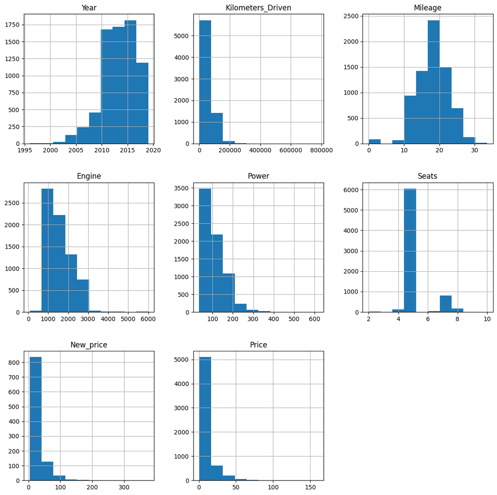

```python
data[num_cols].hist(figsize = (14,14))

plt.show()
```

# Observations

- Price and Kilometer_Driven are right skewed. All outliers need to be imputed.
- Log transformation can help in normalization, Let's do log transformation for Price and Kilometer_Driven.

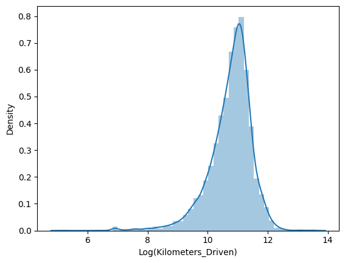

```python
sns.distplot(np.log(data["Kilometers_Driven"]), axlabel = "Log(Kilometers_Driven)");
```

```python
# We can add a transformed kilometers_driven feature in data
data["kilometers_driven_log"] = np.log(data["Kilometers_Driven"])
```

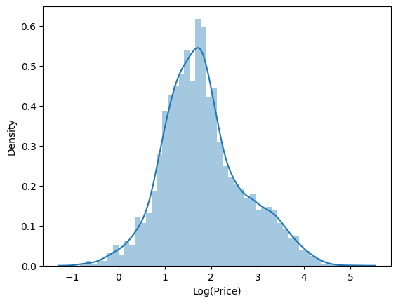

```python
sns.distplot(np.log(data["Price"]), axlabel = "Log(Price)");
```

```python
data["Price_log"] = np.log(data["Price"])
```

# Univariate analysis for categorical variables

```python
for i in cat_cols:
    print(data[i].value_counts(normalize = True))

    print('*' * 40)
```

```
Mahindra XUV500 W8 2WD                  0.007584
Maruti Swift VDI                        0.006757
Maruti Swift Dzire VDI                  0.005792
Honda City 1.5 S MT                     0.005378
Maruti Swift VDI BSIV                   0.005102
                                          ...
Tata Manza Aura Plus Quadrajet BS IV    0.000138
Tata Indigo eCS LS (TDI) BS-III         0.000138
Hyundai Grand i10 Era                   0.000138
Ford Figo Diesel                        0.000138
Hyundai Elite i20 Magna Plus            0.000138
Name: Name, Length: 2041, dtype: float64
Mumbai        0.130860
Hyderabad     0.120794
Coimbatore    0.106453
Kochi         0.106453
Pune          0.105488
Delhi         0.091009
Kolkata       0.090182
Chennai       0.081357
Jaipur        0.068809
Bangalore     0.060673
Ahmedabad     0.037921
Name: Location, dtype: float64
Diesel      0.531026
Petrol      0.458494
CNG         0.008549
LPG         0.001655
Electric    0.000276
Name: Fuel_Type, dtype: float64
Manual       0.717595
Automatic    0.282405
Name: Transmission, dtype: float64
First             0.820601
Second            0.158853
Third             0.018891
Fourth & Above    0.001655
Name: Owner_Type, dtype: float64
```

# Observations

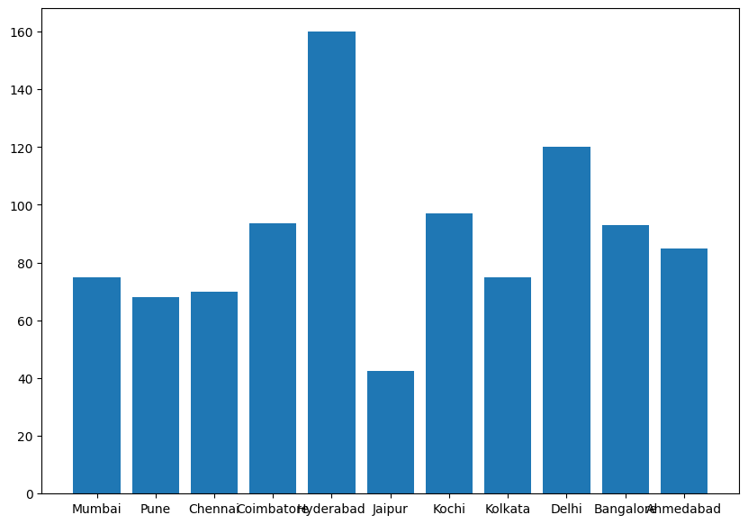

```python
fig = plt.figure(figsize =(10, 7))

# Horizontal Bar Plot
plt.bar(data['Location'], data['Price'])

# Show Plot
plt.show()
```

## Bivariate Analysis

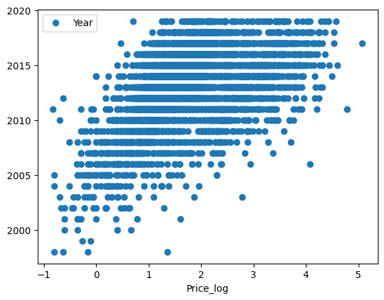

```python
# Let us plot pair plot for the variables 'year' and 'price_log'
data.plot(x = 'Price_log', y = 'Year', style = 'o')
```

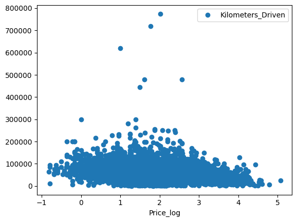

```python
data.plot(x = 'Price_log', y = 'Kilometers_Driven', style = 'o')
```

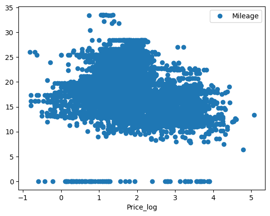

```python
data.plot(x = 'Price_log', y = 'Mileage', style = 'o')
```

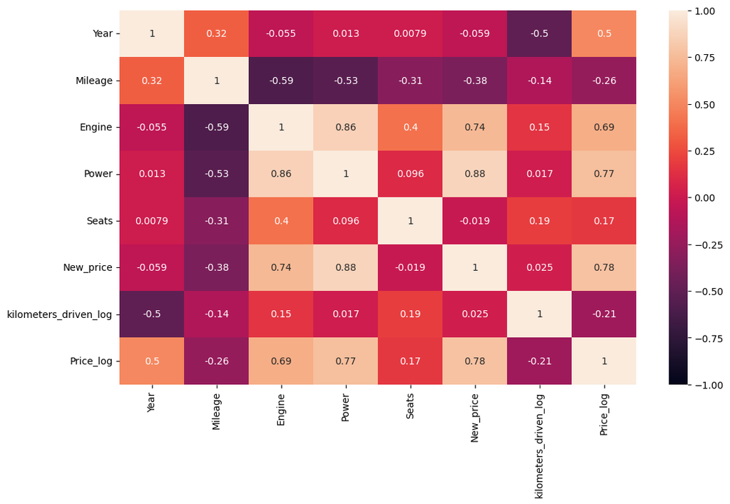

```python
# We can include the log transformation values and drop the original skewed data columns
plt.figure(figsize = (12, 7))

sns.heatmap(data.drop(['Price','Kilometers_Driven'],axis = 1).corr(), annot = True, vmin = -1, vmax = 1)

plt.show()
```

# Observations

- Engine, Power, Price and New_price are highly correlated with each other.

```python
# Let us write a function that will help us create boxplot w.r.t Price for any input categorical variable.
# This function takes the categorical column as the input and returns the boxplots for the variable.
def boxplot(z):

    plt.figure(figsize = (12, 5)) # Setting size of boxplot

    sns.boxplot(x = z, y = data['Price']) # Defining x and y

    plt.show()

    plt.figure(figsize = (12, 5))

    plt.title('Without Outliers')

    sns.boxplot(x = z, y = data['Price'], showfliers = False) # Turning off the outliers

    plt.show()
```

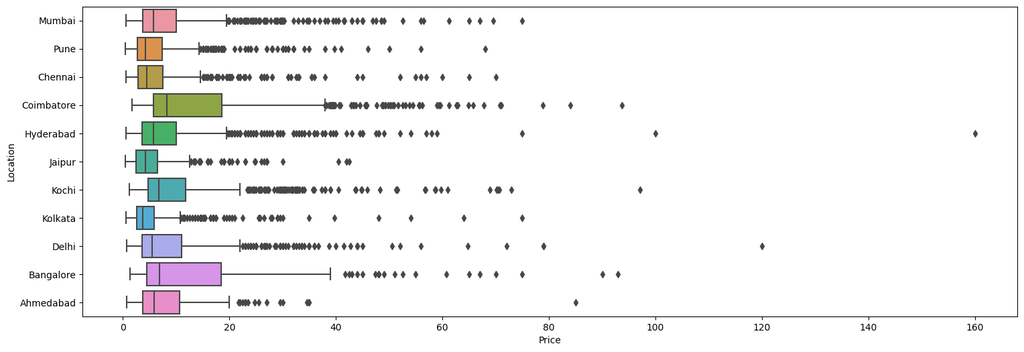

```python
# Box Plot: Price vs Location
fig = plt.figure(figsize = (18, 6))

sns.boxplot(x = 'Price', y = 'Location', data = data);
```

### **Feature Engineering**

Name of the car which includes Brand name and Model name, so we split tht Name and introduce new variables 'Brand' and 'Model'.

```python
data['Brand'] = data.Name.str.split().str.get(0)
data['Model'] = data.Name.str.split().str.get(1) + data.Name.str.split().str.get(2)
data[['Name','Brand','Model']]
```

|  | Name | Brand | Model |
| --- | --- | --- | --- |
| 0 | Maruti Wagon R LXI CNG | Maruti | WagonR |
| 1 | Hyundai Creta 1.6 CRDi SX Option | Hyundai | Creta1.6 |
| 2 | Honda Jazz V | Honda | JazzV |
| 3 | Maruti Ertiga VDI | Maruti | ErtigaVDI |
| 4 | Audi A4 New 2.0 TDI Multitronic | Audi | A4New |
| ... | ... | ... | ... |
| 7248 | Volkswagen Vento Diesel Trendline | Volkswagen | VentoDiesel |
| 7249 | Volkswagen Polo GT TSI | Volkswagen | PoloGT |
| 7250 | Nissan Micra Diesel XV | Nissan | MicraDiesel |
| 7251 | Volkswagen Polo GT TSI | Volkswagen | PoloGT |
| 7252 | Mercedes-Benz E-Class 2009-2013 E 220 CDI Avan... | Mercedes-Benz | E-Class2009-2013 |

7252 rows × 3 columns

### **Missing value treatment**

```python
data.isna().sum()
```

[output not shown]

```python
data.loc[data["Mileage"]==0.0,'Mileage']=np.nan
data.Mileage.isnull().sum()
```

```
83
```

```python
data['Mileage'].fillna(value=np.mean(data['Mileage']),inplace=True)
data.Mileage.isnull().sum()
```

```
0
```

```python
data.loc[data["Seats"]==0.0,'Seats']=np.nan
data['Seats'].fillna(value=np.mean(data['Seats']),inplace=True)
data.Seats.isnull().sum()
```

```
0
```

```python
data.loc[data["Engine"]==0.0,'Engine']=np.nan
data['Engine'].fillna(value=np.mean(data['Engine']),inplace=True)
data.Engine.isnull().sum()
```

```
0
```

```python
data.loc[data["Power"]==0.0,'Power']=np.nan
data['Power'].fillna(value=np.mean(data['Power']),inplace=True)
data.Power.isnull().sum()
```

```
0
```

```python
data.loc[data["Price_log"]==0.0,'Price_log']=np.nan
data['Price_log'].fillna(value=np.mean(data['Price_log']),inplace=True)
data.Price_log.isnull().sum()
```

```python
data.loc[data["Price"]==0.0,'Price']=np.nan
data['Price'].fillna(value=np.mean(data['Price']),inplace=True)
data.Price.isnull().sum()
```

```
0
```

```python
data.loc[data["New_price"]==0.0,'New_price']=np.nan
data['New_price'].fillna(value=np.mean(data['New_price']),inplace=True)
data.New_price.isnull().sum()
```

```
0
```

```python
data.isna().sum()
```

```
Name                     0
Location                 0
Year                     0
Kilometers_Driven        0
Fuel_Type                0
Transmission             0
Owner_Type               0
Mileage                  0
Engine                   0
Power                    0
Seats                    0
New_price                0
Price                    0
kilometers_driven_log    0
Price_log                0
dtype: int64
```

## **Building Various Models**

### **Split the Data**

Step1: Seperating the indepdent variables (X) and the dependent variable (y).

Step2: Encode the categorical variables in X using pd.dummies.

Step3: Split the data into train and test using train_test_split.

```python
y = data.Price_log

X = data.drop(['Price','New_price','Price_log'], axis = 1)
```

```python
X = data.drop(['Price','Price_log','Kilometers_Driven','New_price'], axis = 1)

y = data[["Price",'Price_log']]
```

```python
X = pd.get_dummies(X, drop_first = True)
```

```python
X_train, X_test, y_train, y_test = train_test_split(X, y, test_size = 0.3, random_state = 1)

print(X_train.shape, X_test.shape)
```

```
(5076, 2064) (2176, 2064)
```

```python
# Let us write a function for calculating r2_score and RMSE on train and test data
# This function takes model as an input on which we have trained particular algorithm
# The categorical column as the input and returns the boxplots and histograms for the variable

def get_model_score(model, flag = True):
    '''
    model : regressor to predict values of X

    '''
    # Defining an empty list to store train and test results
    score_list = []

    pred_train = model.predict(X_train)

    pred_train_ = np.exp(pred_train)

    pred_test = model.predict(X_test)

    pred_test_ = np.exp(pred_test)

    train_r2 = metrics.r2_score(y_train['Price'], pred_train_)

    test_r2 = metrics.r2_score(y_test['Price'], pred_test_)

    train_rmse = metrics.mean_squared_error(y_train['Price'], pred_train_, squared = False)

    test_rmse = metrics.mean_squared_error(y_test['Price'], pred_test_, squared = False)

    # Adding all scores in the list
    score_list.extend((train_r2, test_r2, train_rmse, test_rmse))

    # If the flag is set to True then only the following print statements will be dispayed, the default value is True
    if flag == True:

        print("R-sqaure on training set : ", metrics.r2_score(y_train['Price'], pred_train_))

        print("R-square on test set : ", metrics.r2_score(y_test['Price'], pred_test_))

        print("RMSE on training set : ", np.sqrt(metrics.mean_squared_error(y_train['Price'], pred_train_)))

        print("RMSE on test set : ", np.sqrt(metrics.mean_squared_error(y_test['Price'], pred_test_)))

    # Returning the list with train and test scores
    return score_list
```

# Fitting a linear model

```python
# Import Linear Regression from sklearn
from sklearn.linear_model import LinearRegression
```

```python
# Create a linear regression model
lr = LinearRegression()
```

```python
# Fit linear regression model
lr.fit(X_train, y_train['Price'])
```

```
LinearRegression()
```

```python
# Get score of the model
LR_score = get_model_score(lr)
```

```
R-sqaure on training set :  -1.8021432163267625e+133
R-square on test set :  -2.0697104289034037e+59
RMSE on training set :  4.308799620386937e+67
RMSE on test set :  4.6492333810485564e+30
```

```python
ridge = Ridge(alpha= .3)
ridge.fit(X_train, y_train['Price'])
print("Ridge model:", (ridge.coef_))
```

```
Ridge model: [ 0.70651047 -0.10689229  0.00209228 ...  0.88337365 -0.26358853
 -0.16288378]
```

```python
lasso =Lasso(alpha=0.1)
lasso.fit(X_train, y_train['Price'])
print("Lasso model:", (lasso.coef_))
```

```
Lasso model: [ 0.6806785   0.          0.00185967 ...  0.         -0.
  0.        ]
```

```python
Ridge_score = get_model_score(ridge)
```

```
R-sqaure on training set :  -6.433741804870406e+107
R-square on test set :  -6.744112299774619e+50
RMSE on training set :  8.141294427146233e+54
RMSE on test set :  2.6539268606332784e+26
```

```python
Lasso_score = get_model_score(lasso)
```

```
R-sqaure on training set :  -3.5315746370733154e+52
R-square on test set :  -2.6105591571034766e+50
RMSE on training set :  1.9074178462805237e+27
RMSE on test set :  1.651175830393408e+26
```

```python
print(lr.score(X_train, y_train['Price']))
print(lr.score(X_test, y_test['Price']))
```

```
0.8906480135224399
0.3163943364536891
```

```python
print(ridge.score(X_train, y_train['Price']))
print(ridge.score(X_test, y_test['Price']))
```

```
0.8812829291657815
0.7018273878049098
```

```python
print(lasso.score(X_train, y_train['Price']))
print(lasso.score(X_test, y_test['Price']))
```

```
0.5777864054312429
0.6198014319446785
```

# LR #RIDGE (L2) #LASSO (L1)

31%. 70.1%. 61.9%

Certainly, there is an impact on the model due to the Regularization L2 and L1.

## Compare L2 and L1 Regularization

# Observations

- The Train and the test scores are not close to each other for RMSE, so the Model is overfitting.

Building a model using statsmodels.

```python
# Import Statsmodels
import statsmodels.api as sm

# Statsmodel api does not add a constant by default. We need to add it explicitly
x_train = sm.add_constant(X_train)

# Add constant to test data
x_test = sm.add_constant(X_test)

def build_ols_model(train):

    # Create the model
    olsmodel = sm.OLS(y_train["Price"], train)

    return olsmodel.fit()


# Fit linear model on new dataset
olsmodel1 = build_ols_model(x_train)

print(olsmodel1.summary())
```

```
                            OLS Regression Results
==============================================================================
Dep. Variable:                  Price   R-squared:                       0.891
Model:                            OLS   Adj. R-squared:                  0.833
Method:                 Least Squares   F-statistic:                     15.37
Date:                Fri, 20 Oct 2023   Prob (F-statistic):               0.00
Time:                        01:10:45   Log-Likelihood:                -13349.
No. Observations:                5076   AIC:                         3.022e+04
Df Residuals:                    3317   BIC:                         4.171e+04
Df Model:                        1758
Covariance Type:            nonrobust
====================================================================================================================================
                                                                       coef    std err          t      P>|t|      [0.025      0.975]
------------------------------------------------------------------------------------------------------------------------------------
const                                                            -1339.7625    102.409    -13.082      0.000   -1540.554   -1138.971
Year                                                                 0.7107      0.052     13.736      0.000       0.609       0.812
Mileage                                                             -0.0316      0.109     -0.289      0.772      -0.246       0.183
Engine                                                               0.0015      0.012      0.123      0.902      -0.022       0.025
Power                                                                0.0265      0.030      0.881      0.378      -0.032       0.086
Seats                                                               -0.0156      2.419     -0.006      0.995      -4.759       4.728
kilometers_driven_log                                               -0.7664      0.156     -4.898      0.000      -1.073      -0.460
Name_Audi A3 35 TDI Attraction                                     -17.5390      4.201     -4.175      0.000     -25.776      -9.301
Name_Audi A3 35 TDI Premium                                      -3.695e-10   1.12e-10     -3.290      0.001    -5.9e-10   -1.49e-10
Name_Audi A3 35 TDI Premium Plus                                   -17.7377      4.195     -4.228      0.000     -25.963      -9.513
Name_Audi A3 35 TDI Technology                                   -1.342e-10   4.95e-11     -2.712      0.007   -2.31e-10   -3.72e-11
Name_Audi A4 1.8 TFSI                                                6.4302      5.933      1.084      0.279      -5.203      18.063
Name_Audi A4 1.8 TFSI Technology Edition                         -4.876e-10   1.49e-10     -3.263      0.001   -7.81e-10   -1.95e-10
Name_Audi A4 2.0 TDI                                               -15.5743      3.130     -4.975      0.000     -21.712      -9.437
Name_Audi A4 2.0 TDI 177 Bhp Premium Plus                          -11.7500      3.193     -3.680      0.000     -18.010      -5.490
Name_Audi A4 2.0 TDI 177 Bhp Technology Edition                    -12.0819      3.794     -3.184      0.001     -19.521      -4.643
Name_Audi A4 2.0 TDI Celebration Edition                         -1.022e-09   2.88e-10     -3.553      0.000   -1.59e-09   -4.58e-10
Name_Audi A4 2.0 TDI Multitronic                                   -15.0757      3.658     -4.121      0.000     -22.248      -7.903
Name_Audi A4 2.0 TDI Premium Sport Limited Edition                 -13.6529      3.791     -3.602      0.000     -21.086      -6.220
Name_Audi A4 2.0 TFSI                                                9.2340      5.527      1.671      0.095      -1.603      20.071
Name_Audi A4 3.0 TDI Quattro                                       -11.6819     10.464     -1.116      0.264     -32.199       8.835
Name_Audi A4 3.0 TDI Quattro Premium                               -21.2572     10.459     -2.033      0.042     -41.763      -0.751
Name_Audi A4 3.2 FSI Tiptronic Quattro                            5.035e-10   1.66e-10      3.036      0.002    1.78e-10    8.29e-10
Name_Audi A4 30 TFSI Premium Plus                                 1.044e-10   2.75e-11      3.794      0.000    5.04e-11    1.58e-10
Name_Audi A4 35 TDI Premium                                         -8.4209      3.600     -2.339      0.019     -15.479      -1.363
Name_Audi A4 35 TDI Premium Plus                                   -17.0423      3.852     -4.425      0.000     -24.594      -9.490
```

[output cut: 2035 more lines]

```
Transmission_Manual                                                -17.8703      9.541     -1.873      0.061     -36.578       0.837
Owner_Type_Fourth & Above                                            0.4100      1.731      0.237      0.813      -2.985       3.805
Owner_Type_Second                                                   -0.2718      0.220     -1.238      0.216      -0.702       0.159
Owner_Type_Third                                                    -0.5683      0.629     -0.904      0.366      -1.801       0.664
==============================================================================
Omnibus:                     1801.537   Durbin-Watson:                   2.039
Prob(Omnibus):                  0.000   Jarque-Bera (JB):            92775.576
Skew:                          -0.920   Prob(JB):                         0.00
Kurtosis:                      23.863   Cond. No.                     1.96e+21
==============================================================================

Notes:
[1] Standard Errors assume that the covariance matrix of the errors is correctly specified.
[2] The smallest eigenvalue is 9.03e-33. This might indicate that there are
strong multicollinearity problems or that the design matrix is singular.
```

```python
# Retrive Coeff values, p-values and store them in the dataframe
olsmod = pd.DataFrame(olsmodel1.params, columns = ['coef'])

olsmod['pval'] = olsmodel1.pvalues
```

```python
# Filter by significant p-value (pval <= 0.05) and sort descending by Odds ratio

olsmod = olsmod.sort_values(by = "pval", ascending = False)

pval_filter = olsmod['pval']<= 0.05

olsmod[pval_filter]
```

|  | coef | pval |
| --- | --- | --- |
| Name_Maruti Celerio ZXI MT | 18.922079 | 4.924989e-02 |
| Name_Porsche Cayman 2009-2012 S | 51.827412 | 4.917770e-02 |
| Name_Maruti Ignis 1.2 Delta | 16.554289 | 4.887358e-02 |
| Name_Maruti Alto K10 VXI | 18.223533 | 4.884463e-02 |
| Name_Volvo S60 D4 SUMMUM | -10.031422 | 4.864060e-02 |
| ... | ... | ... |
| Name_Maruti Eeco 5 STR With AC Plus HTR CNG | -65.627829 | 2.158857e-29 |
| Fuel_Type_LPG | -53.296758 | 1.077683e-33 |
| Name_Maruti Wagon R LXI CNG | -63.806686 | 2.325303e-34 |
| const | -1339.762453 | 3.597440e-38 |
| Year | 0.710654 | 8.439626e-42 |

912 rows × 2 columns

```python
# We are looking are overall significant varaible

pval_filter = olsmod['pval']<= 0.05
imp_vars = olsmod[pval_filter].index.tolist()

# We are going to get overall varaibles (un-one-hot encoded varables) from categorical varaibles
sig_var = []
for col in imp_vars:
    if '' in col:
        first_part = col.split('_')[0]
        for c in data.columns:
            if first_part in c and c not in sig_var :
                sig_var.append(c)


start = '\033[1m'
end = '\033[95m'
print(start+ 'Most overall significant categorical varaibles of LINEAR REGRESSION  are ' +end,':\n', sig_var)
```

```
Most overall significant categorical varaibles of LINEAR REGRESSION  are  :
 ['Name', 'Fuel_Type', 'Location', 'kilometers_driven_log', 'Year']
```

## Observations

Most overall significant categorical varaibles of LINEAR REGRESSION are : 'Name', 'Fuel_Type', 'Location', 'kilometers_driven_log', 'Year'

### Decision Tree

```python
# Creating a list of columns for which we will create dummy variables
to_get_dummies_for = ['Transmission', 'Location', 'Power', 'Year', 'Name', 'Fuel_Type','Owner_Type']

# Creating dummy variables
data= pd.get_dummies(data = data, columns = to_get_dummies_for, drop_first = True)
```

```python
data.head()
```

|  | Kilometers_Driven | Mileage | Engine | Seats | New_price | Price | kilometers_driven_log | Price_log | Transmission_Manual | Location_Bangalore | ... | Name_Volvo XC60 D5 Inscription | Name_Volvo XC90 2007-2015 D5 AT AWD | Name_Volvo XC90 2007-2015 D5 AWD | Fuel_Type_Diesel | Fuel_Type_Electric | Fuel_Type_LPG | Fuel_Type_Petrol | Owner_Type_Fourth & Above | Owner_Type_Second | Owner_Type_Third |
| --- | --- | --- | --- | --- | --- | --- | --- | --- | --- | --- | --- | --- | --- | --- | --- | --- | --- | --- | --- | --- | --- |
| 0 | 72000 | 26.60 | 998.0 | 5.0 | 22.779692 | 1.75 | 11.184421 | 0.559616 | 1 | 0 | ... | 0 | 0 | 0 | 0 | 0 | 0 | 0 | 0 | 0 | 0 |
| 1 | 41000 | 19.67 | 1582.0 | 5.0 | 22.779692 | 12.50 | 10.621327 | 2.525729 | 1 | 0 | ... | 0 | 0 | 0 | 1 | 0 | 0 | 0 | 0 | 0 | 0 |
| 2 | 46000 | 18.20 | 1199.0 | 5.0 | 8.610000 | 4.50 | 10.736397 | 1.504077 | 1 | 0 | ... | 0 | 0 | 0 | 0 | 0 | 0 | 1 | 0 | 0 | 0 |
| 3 | 87000 | 20.77 | 1248.0 | 7.0 | 22.779692 | 6.00 | 11.373663 | 1.791759 | 1 | 0 | ... | 0 | 0 | 0 | 1 | 0 | 0 | 0 | 0 | 0 | 0 |
| 4 | 40670 | 15.20 | 1968.0 | 5.0 | 22.779692 | 17.74 | 10.613246 | 2.875822 | 0 | 0 | ... | 0 | 0 | 0 | 1 | 0 | 0 | 0 | 0 | 1 | 0 |

5 rows × 2471 columns

```python
# Separating the target variable and other variables

Y = data.Price_log

X = data.drop(['Price','Price_log',"New_price"], axis = 1)
```

```python
x_train, x_test, y_train, y_test = train_test_split(X, Y, test_size = 0.3, random_state = 1)
```

```python
data.isna().sum()
```

```
Kilometers_Driven            0
Mileage                      0
Engine                       0
Seats                        0
New_price                    0
                            ..
Fuel_Type_LPG                0
Fuel_Type_Petrol             0
Owner_Type_Fourth & Above    0
Owner_Type_Second            0
Owner_Type_Third             0
Length: 2471, dtype: int64
```

```python
X.head()
```

[output not shown]

```python
regressor = DecisionTreeRegressor(random_state = 0)
```

```python
# Function to compute adjusted R-squared
def adj_r2_score(predictors, targets, predictions):
    r2 = r2_score(targets, predictions)
    n = predictors.shape[0]
    k = predictors.shape[1]
    return 1 - ((1 - r2) * (n - 1) / (n - k - 1))


# Function to compute MAPE
def mape_score(targets, predictions):
    return np.mean(np.abs(targets - predictions) / targets) * 100


# Function to compute different metrics to check performance of a regression model
def model_performance_regression(model, predictors, target):
    """
    Function to compute different metrics to check regression model performance

    model: regressor
    predictors: independent variables
    target: dependent variable
    """

    pred = model.predict(predictors)                  # Predict using the independent variables
    r2 = r2_score(target, pred)                       # To compute R-squared
    adjr2 = adj_r2_score(predictors, target, pred)    # To compute adjusted R-squared
    rmse = np.sqrt(mean_squared_error(target, pred))  # To compute RMSE
    mae = mean_absolute_error(target, pred)           # To compute MAE

    # Creating a dataframe of metrics
    df_perf = pd.DataFrame(
        {
            "RMSE": rmse,
            "MAE": mae,
            "R-squared": r2,
            "Adj. R-squared": adjr2
        },
        index=[0],
    )

    return df_perf
```

```python
# Fitting decision tree model
regressor.fit(x_train, y_train)
```

```
DecisionTreeRegressor(random_state=0)
```

```python
# Model Performance on the train data, i.e., prediction
dt_regressor_perf_train = model_performance_regression(regressor, x_train, y_train)

dt_regressor_perf_train
```

|  | RMSE | MAE | R-squared | Adj. R-squared |
| --- | --- | --- | --- | --- |
| 0 | 0.007713 | 0.000367 | 0.999905 | 0.999814 |

```python
# Model Performance on the test data, i.e., prediction
dt_regressor_perf_test = model_performance_regression(regressor, x_test, y_test)

dt_regressor_perf_test
```

|  | RMSE | MAE | R-squared | Adj. R-squared |
| --- | --- | --- | --- | --- |
| 0 | 0.546252 | 0.366925 | 0.52836 | 4.501084 |

### Random Forest

```python
from sklearn.ensemble import RandomForestRegressor
```

```python
rf_estimator = RandomForestRegressor(random_state = 1)

rf_estimator.fit(x_train, y_train)
```

```
RandomForestRegressor(random_state=1)
```

```python
# Model Performance on the train data, i.e., prediction
rf_estimator_model_train_perf = model_performance_regression(
    rf_estimator, x_train, y_train
)
rf_estimator_model_train_perf
```

|  | RMSE | MAE | R-squared | Adj. R-squared |
| --- | --- | --- | --- | --- |
| 0 | 0.161399 | 0.108651 | 0.958226 | 0.91868 |

```python
# Model Performance on the test data, i.e., prediction
rf_estimator_model_test_perf = model_performance_regression(
    rf_estimator, x_test, y_test
)
rf_estimator_model_test_perf
```

|  | RMSE | MAE | R-squared | Adj. R-squared |
| --- | --- | --- | --- | --- |
| 0 | 0.418546 | 0.29118 | 0.723107 | 3.055433 |

- Random Forest model is overfitting